# Assignment1

## A. Loading and preprocessing the data

### 1.Load the data (i.e. read.csv())

Load ggplot2 and plyr library

```r
library(ggplot2)
library(plyr)
```

Read data into a new data frame called data

```r
data <- read.csv("activity.csv")
```

### 2.Process/transform the data (if necessary) into a format suitable for your analysis

```r
#Format the date column into date class
data$date <- as.Date(data$date)
#Sort out the NA steps value for further calculation
na <- is.na(data$steps)
cleanData <- data[!na,]
```

## B. What is mean total number of steps taken per day?

### 1.Calculate the total number of steps taken per day

Calculate total number of steps based on the clean data and store in the variable totalSPD

```r
totalSPD <- aggregate(cleanData$steps, by=list(cleanData$date),sum)
#review the newly created dataframe
head(totalSPD)
```

```
##      Group.1     x
## 1 2012-10-02   126
## 2 2012-10-03 11352
## 3 2012-10-04 12116
## 4 2012-10-05 13294
## 5 2012-10-06 15420
## 6 2012-10-07 11015
```

```r
#rename the column
totalSPD <- rename(totalSPD, c("Group.1"="Date","x"="totalsteps"))
#review once again
head(totalSPD)
```

```
##         Date totalsteps
## 1 2012-10-02        126
## 2 2012-10-03      11352
## 3 2012-10-04      12116
## 4 2012-10-05      13294
## 5 2012-10-06      15420
## 6 2012-10-07      11015
```

### 2.Make a histogram of the total number of steps taken each day

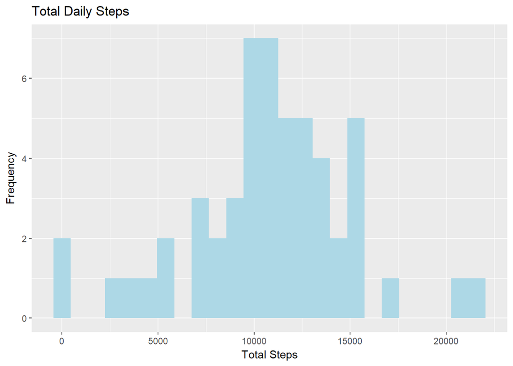

```r
#create object g as layout for the histogram
g <- ggplot(totalSPD, aes(x=totalsteps))
#choose color, dimension and create labels for the histpgram
g + geom_histogram(fill="lightblue", binwidth = 900) + labs(title = "Total Daily Steps", x="Total Steps", y="Frequency")
```

### 3.Calculate and report the mean and median of the total number of steps taken per day

```r
#Mean of steps
mean_og <-mean(totalSPD$totalsteps)
#Median of steps
median_og <-median(totalSPD$totalsteps)
```

## C. What is the average daily activity pattern?

### 1.Make a time series plot (i.e. type = “l”) of the 5-minute interval (x-axis) and the average number of steps taken, averaged across all days (y-axis)

```r
#create a new data frame avgSBI(average steps by interval) based on the cleanData
avgSBI <- aggregate(cleanData$steps, by=list(cleanData$interval),mean)
#rename the column
avgSBI <- rename(avgSBI, c("Group.1"="interval","x"="averagesteps"))
#review the data frame
head(avgSBI)
```

```
##   interval averagesteps
## 1        0    1.7169811
## 2        5    0.3396226
## 3       10    0.1320755
## 4       15    0.1509434
## 5       20    0.0754717
## 6       25    2.0943396
```

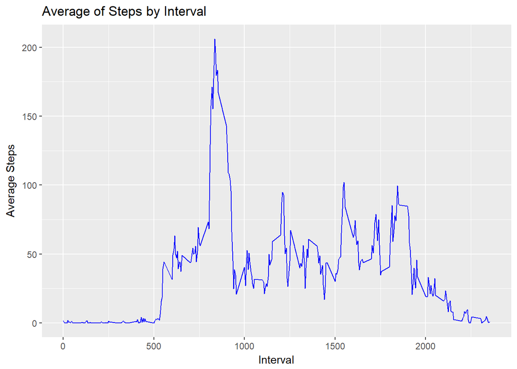

```r
#create the new object "p" to make the plot as required
p <- ggplot(avgSBI, aes(x=interval,y=averagesteps), type="l")
# create the time series plot
p + geom_line(color="blue") + labs(title="Average of Steps by Interval", x="Interval", y="Average Steps")
```

### 2.Which 5-minute interval, on average across all the days in the dataset, contains the maximum number of steps?

```r
# Find the max Average steps value and store it in the new variable "maxSteps"
maxSteps <- avgSBI[which.max(avgSBI$averagesteps),]
# Review the value
maxSteps
```

```
##     interval averagesteps
## 104      835     206.1698
```

## D. Imputing missing values

### 1.Calculate and report the total number of missing values in the dataset (i.e. the total number of rows with NAs)

```r
# Count the total number of missing value by using the variable "na" defined in the A part of the assignment
sum(na)
```

```
## [1] 2304
```

### 2.Devise a strategy for filling in all of the missing values in the dataset

```r
#The average steps by Interval will be used to replace the na value
#Create a new variable meanSI to store the average steps by interval based on the original data frame
meanSI <- aggregate(steps~interval,data,FUN=mean)
#Create a new dataframe that merges the original data frame with the means of steps by interval
newData <- merge(x=data,y=meanSI,by="interval")
#Take a sneakpeak at the new dataframe:
str(newData)
```

```
## 'data.frame':    17568 obs. of  4 variables:
##  $ interval: int  0 0 0 0 0 0 0 0 0 0 ...
##  $ steps.x : int  NA 0 0 0 0 0 0 0 0 0 ...
##  $ date    : Date, format: "2012-10-01" "2012-11-23" ...
##  $ steps.y : num  1.72 1.72 1.72 1.72 1.72 ...
```

```r
#Replace na steps values in newData with average steps by interval, create a new column called steps
newData$steps <- ifelse(is.na(newData$steps.x),newData$steps.y,newData$steps.x)
```

### 3.Create a new dataset that is equal to the original dataset but with the missing data filled in.

```r
head(newData)
```

```
##   interval steps.x       date  steps.y    steps
## 1        0      NA 2012-10-01 1.716981 1.716981
## 2        0       0 2012-11-23 1.716981 0.000000
## 3        0       0 2012-10-28 1.716981 0.000000
## 4        0       0 2012-11-06 1.716981 0.000000
## 5        0       0 2012-11-24 1.716981 0.000000
## 6        0       0 2012-11-15 1.716981 0.000000
```

### 4.Make a histogram of the total number of steps taken each day and Calculate and report the mean and median total number of steps taken per day

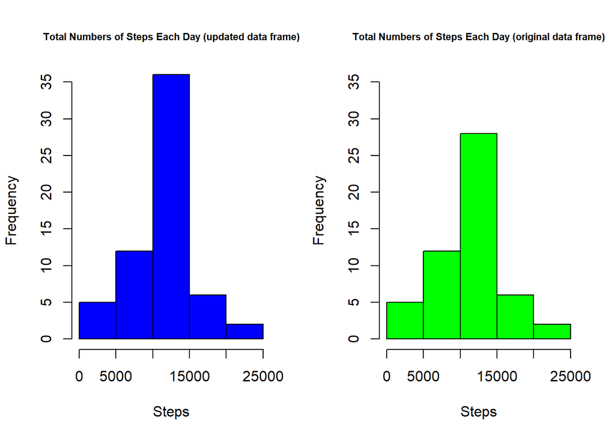

```r
#Total steps by day based on new data frame
totalSPD_new <- aggregate(steps~date,newData,FUN=sum)
##Set up plot to compare old and new data frame
par(mfrow=c(1,2))
hist(totalSPD_new$steps, col="blue", ylim=c(0,35),xlab = "Steps", ylab ="Frequency",
     main= "Total Numbers of Steps Each Day (updated data frame)", cex.main=0.7)
hist(totalSPD$totalsteps, col="green", ylim=c(0,35),xlab = "Steps", ylab ="Frequency",
     main= "Total Numbers of Steps Each Day (original data frame)",cex.main=0.7)
```

```r
#comparing the old and new mean/median between the original and updated data frame
par(mfrow=c(2,1))
newmean <- mean(totalSPD_new$steps)
newmedian <- median(totalSPD_new$steps)
paste("New mean:  ",round(newmean,2),", ","Original mean  :",round(mean_og,2),"Difference  :", round(newmean-mean_og,2))
```

```
## [1] "New mean:   10766.19 ,  Original mean  : 10766.19 Difference  : 0"
```

```r
paste("New median:  ",round(newmedian,2),", ","Original median  :",round(median_og,2),"Difference  :", round(newmedian-median_og,2))
```

```
## [1] "New median:   10766.19 ,  Original median  : 10765 Difference  : 1.19"
```

## E. Are there differences in activity patterns between weekdays and weekends?

### 1.Create a new factor variable in the dataset with two levels - “weekday” and “weekend” indicating whether a given date is a weekday or weekend day.

```r
#Install packages "chron" to use the function is.weekend
library(chron)
#Create a new variable "day" to sort out Weekday/Weekend in the new data frame
newData$day <- ifelse(is.weekend(newData$date),"Weekend","Weekday")
head(newData)
```

```
##   interval steps.x       date  steps.y    steps     day
## 1        0      NA 2012-10-01 1.716981 1.716981 Weekday
## 2        0       0 2012-11-23 1.716981 0.000000 Weekday
## 3        0       0 2012-10-28 1.716981 0.000000 Weekend
## 4        0       0 2012-11-06 1.716981 0.000000 Weekday
## 5        0       0 2012-11-24 1.716981 0.000000 Weekend
## 6        0       0 2012-11-15 1.716981 0.000000 Weekday
```

```r
#Create new table with average steps over interval and day of week
meanSI_new <- aggregate(steps~interval+day,newData,FUN=mean)
head(meanSI_new)
```

```
##   interval     day      steps
## 1        0 Weekday 2.25115304
## 2        5 Weekday 0.44528302
## 3       10 Weekday 0.17316562
## 4       15 Weekday 0.19790356
## 5       20 Weekday 0.09895178
## 6       25 Weekday 1.59035639
```

### 2.Make a panel plot containing a time series plot (i.e. type = “l”) of the 5-minute interval (x-axis) and the average number of steps taken, averaged across all weekday days or weekend days (y-axis)

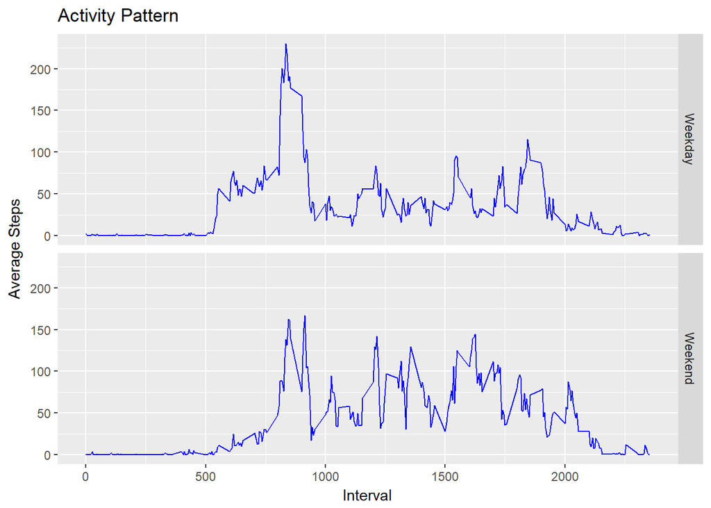

```r
#Create plot to compare activity pattern between weekday and weekend
ggplot(meanSI_new, aes(x=interval, y=steps),type="l") + geom_line(color="blue", size=0.5) +facet_grid(day~.) +labs(x="Interval", y="Average Steps", title = "Activity Pattern")
```